# Using temperature to describe stress

Mikaela M. Provost

7/23/2020

## Goals

Overal goal is to develop a method that defines stress through time based on a time series of temperature. Before running our stress model, I want to calibrate SST to match *in situ* temperature at depth. We have lots of *in situ* data, but we have so much more SST.

What data do we have?

- *In situ* daily temperature observations ( 9/12/2015 – 8/17/2018) in two locations, Morro Prieto and Punta Prieta.
- Daily SST for a longer period of time (2009-2019) in both locations.

### Calculate the average difference between SST and *in situ* temp

1. Find the average temperature per Julian day (at each site, for *in situ* and for SST).
2. Calculate a smoothed monthly moving average.
3. For each Julian day, calculate the difference between the moving average of SST and *in situ*.
4. Use this daily-offset to adjust daily SST temperatures.

#### 1) Plot the raw temperature at each location.

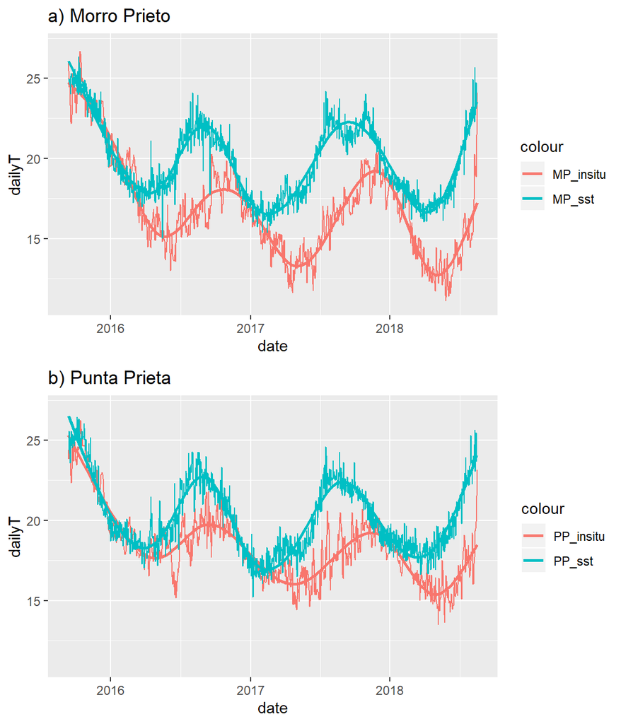

#### 2) Plot the average temperature per Julian day. The daily offset is calculated from this plot: SSTmean - instmean (for each julian day). The daily offset is substracted from raw daily SST (see fig 3)

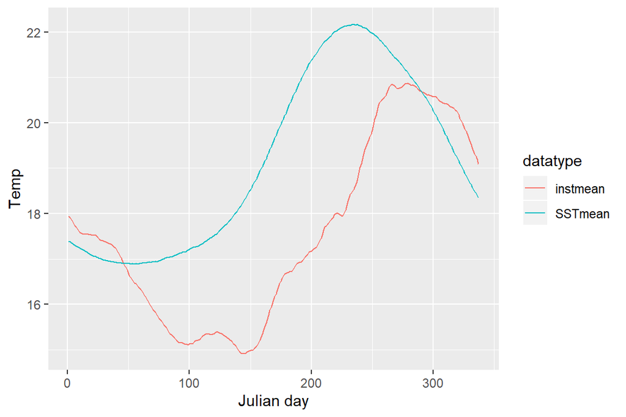

#### 3) Compare raw SST with the adjusted SST (SST-offset)

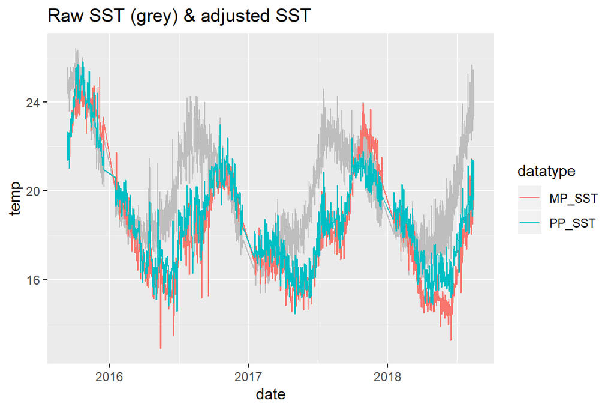

#### 4) Overlay the adjusted SST with *in situ* time series – do they match?

Does the daily SST offset work?

- Sort of. The peaks and troughs appear to line up more closely than the raw SST data
- Mean temperature per day in the adjusted SST time series doesn’t overlap the mean *in situ* throughout the year (this is bad)
- In some years there is better overlap compared to other years.

Offset in SST is based on an average of in situ data at both Morro Prieto and Punta Prieta.

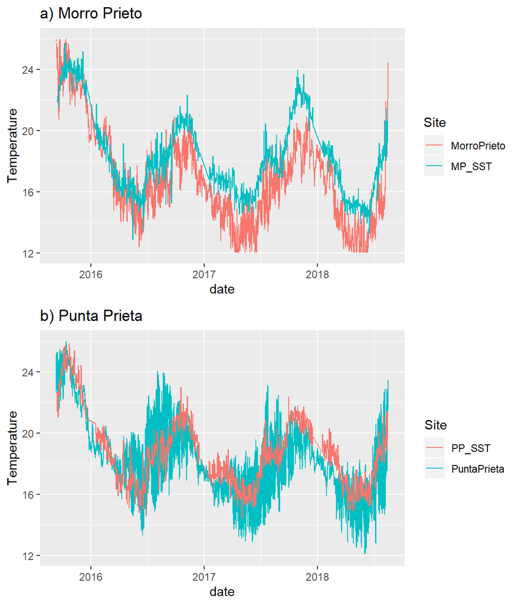

#### 5) Apply stress model to adjusted SST & *in situ* time series

##### Daily stress in 2016 using *in situ* time series and adjusted SST time series

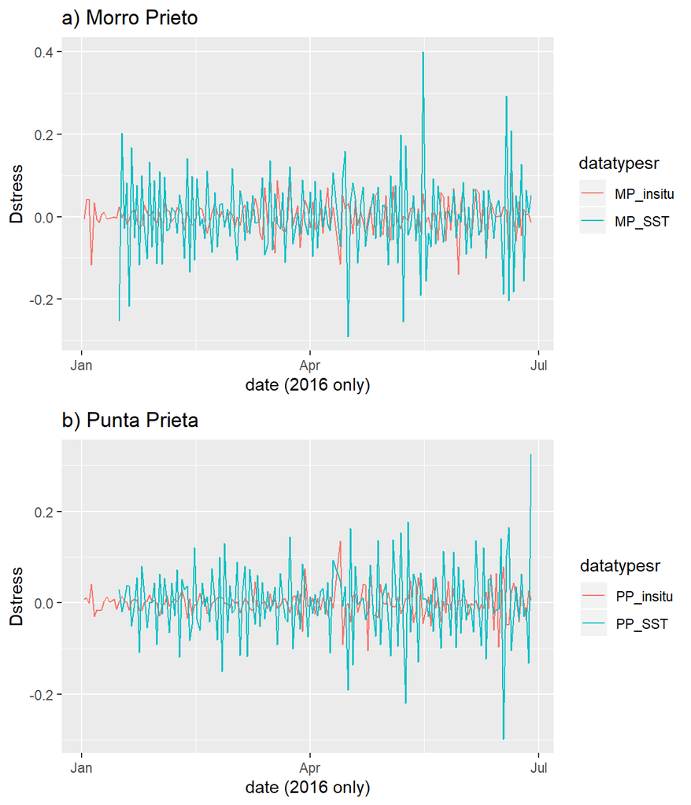

## Approach #2: apply the stress model on raw SST and *in situ* time series

#### As before, here are the raw temperatures at each location

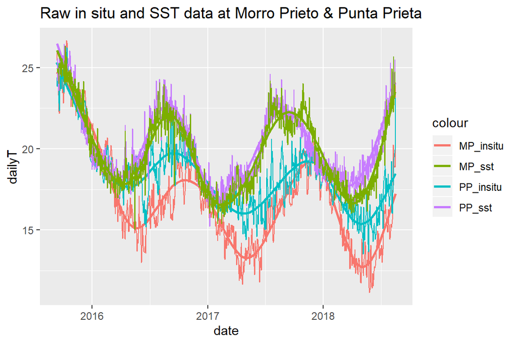

We could run the stress model on these time series and calculate the offset needed to adjust the SST stress time series so that it matches the *in situ* stress time series.

As with the other method, this is a statistical approach and not a mechanistic one.

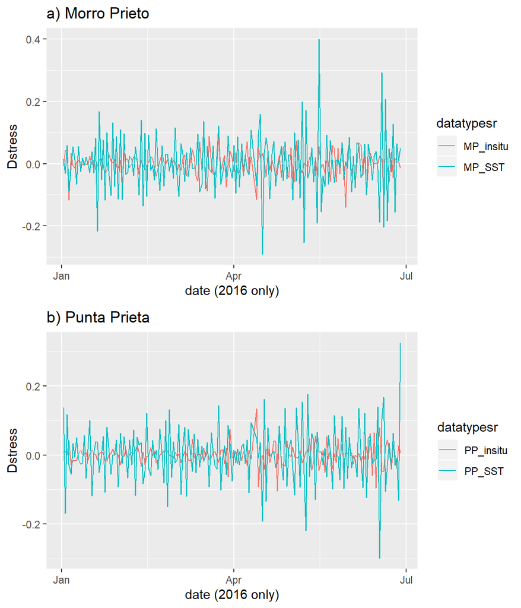